# EDA: Project Red Wine

# Introduction to this dataset

This dataset was created by P. Cortez, A. Cerdeira, F. Almeida, T. Matos and J. Reis. (Source) to study the components and the resulting quality of the red wine. This dataset is using the red wine samples from Vinho Verde. Three wine experts graded the wine quality and their score range from 0 (the worst) to 10 (the best). Since this dataset is dealing with red wine quality, we will then explore them by relating the factors that contributes to the quality of wine.

# Data Overview

First, we will be looking at the structure of this dataset

```r
str(rw)
```

```
## 'data.frame':    1599 obs. of  13 variables:
##  $ X                   : int  1 2 3 4 5 6 7 8 9 10 ...
##  $ fixed.acidity       : num  7.4 7.8 7.8 11.2 7.4 7.4 7.9 7.3 7.8 7.5 ...
##  $ volatile.acidity    : num  0.7 0.88 0.76 0.28 0.7 0.66 0.6 0.65 0.58 0.5 ...
##  $ citric.acid         : num  0 0 0.04 0.56 0 0 0.06 0 0.02 0.36 ...
##  $ residual.sugar      : num  1.9 2.6 2.3 1.9 1.9 1.8 1.6 1.2 2 6.1 ...
##  $ chlorides           : num  0.076 0.098 0.092 0.075 0.076 0.075 0.069 0.065 0.073 0.071 ...
##  $ free.sulfur.dioxide : num  11 25 15 17 11 13 15 15 9 17 ...
##  $ total.sulfur.dioxide: num  34 67 54 60 34 40 59 21 18 102 ...
##  $ density             : num  0.998 0.997 0.997 0.998 0.998 ...
##  $ pH                  : num  3.51 3.2 3.26 3.16 3.51 3.51 3.3 3.39 3.36 3.35 ...
##  $ sulphates           : num  0.56 0.68 0.65 0.58 0.56 0.56 0.46 0.47 0.57 0.8 ...
##  $ alcohol             : num  9.4 9.8 9.8 9.8 9.4 9.4 9.4 10 9.5 10.5 ...
##  $ quality             : int  5 5 5 6 5 5 5 7 7 5 ...
```

From the above result, we noticed that variable x is an index to this dataset. It is not needed for this analysis. So we will remove it.

```r
rw$X <- NULL
str(rw)
```

```
## 'data.frame':    1599 obs. of  12 variables:
##  $ fixed.acidity       : num  7.4 7.8 7.8 11.2 7.4 7.4 7.9 7.3 7.8 7.5 ...
##  $ volatile.acidity    : num  0.7 0.88 0.76 0.28 0.7 0.66 0.6 0.65 0.58 0.5 ...
##  $ citric.acid         : num  0 0 0.04 0.56 0 0 0.06 0 0.02 0.36 ...
##  $ residual.sugar      : num  1.9 2.6 2.3 1.9 1.9 1.8 1.6 1.2 2 6.1 ...
##  $ chlorides           : num  0.076 0.098 0.092 0.075 0.076 0.075 0.069 0.065 0.073 0.071 ...
##  $ free.sulfur.dioxide : num  11 25 15 17 11 13 15 15 9 17 ...
##  $ total.sulfur.dioxide: num  34 67 54 60 34 40 59 21 18 102 ...
##  $ density             : num  0.998 0.997 0.997 0.998 0.998 ...
##  $ pH                  : num  3.51 3.2 3.26 3.16 3.51 3.51 3.3 3.39 3.36 3.35 ...
##  $ sulphates           : num  0.56 0.68 0.65 0.58 0.56 0.56 0.46 0.47 0.57 0.8 ...
##  $ alcohol             : num  9.4 9.8 9.8 9.8 9.4 9.4 9.4 10 9.5 10.5 ...
##  $ quality             : int  5 5 5 6 5 5 5 7 7 5 ...
```

Once we removed variable X, we can see that this dataset contains 1599 observations with 12 variables. The explanations on the variables can be found below:-

Input variables (based on physicochemical tests): 1 - fixed acidity (tartaric acid - g / dm^3) 2 - volatile acidity (acetic acid - g / dm^3) 3 - citric acid (g / dm^3) 4 - residual sugar (g / dm^3) 5 - chlorides (sodium chloride - g / dm^3 6 - free sulfur dioxide (mg / dm^3) 7 - total sulfur dioxide (mg / dm^3) 8 - density (g / cm^3) 9 - pH 10 - sulphates (potassium sulphate - g / dm3) 11 - alcohol (% by volume)

Output variable (based on sensory data): 12 - quality (score between 0 and 10)

[(Source)](https://s3.amazonaws.com/udacity-hosted-downloads/ud651/wineQualityInfo.txt)

# Univariate Plots Section

The first step is to compare all the histogram variables in this dataset. This is just to get a general outlook on the type of distribution we’re dealing with. We will start with Fixed Acidity variable.

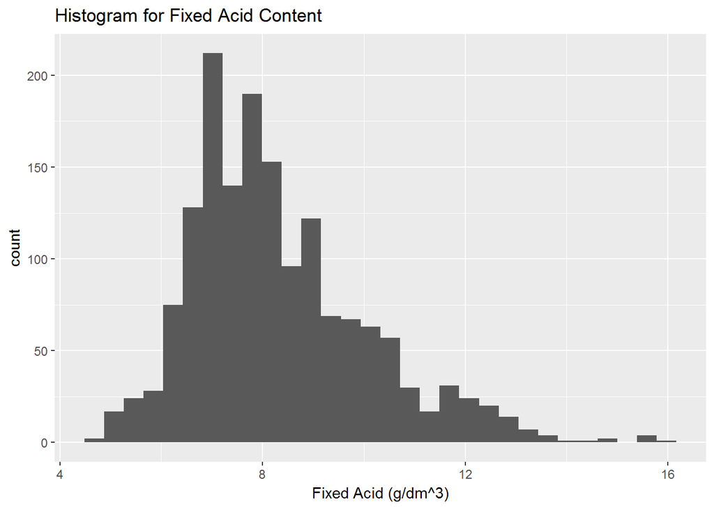

```r
summary(rw$fixed.acid)
```

```
##    Min. 1st Qu.  Median    Mean 3rd Qu.    Max.
##    4.60    7.10    7.90    8.32    9.20   15.90
```

There are two peaks in this histogram, and both of them lies in between 7 to 8g/dm^3). Some outliers were detected at 15-16g/dm^3.

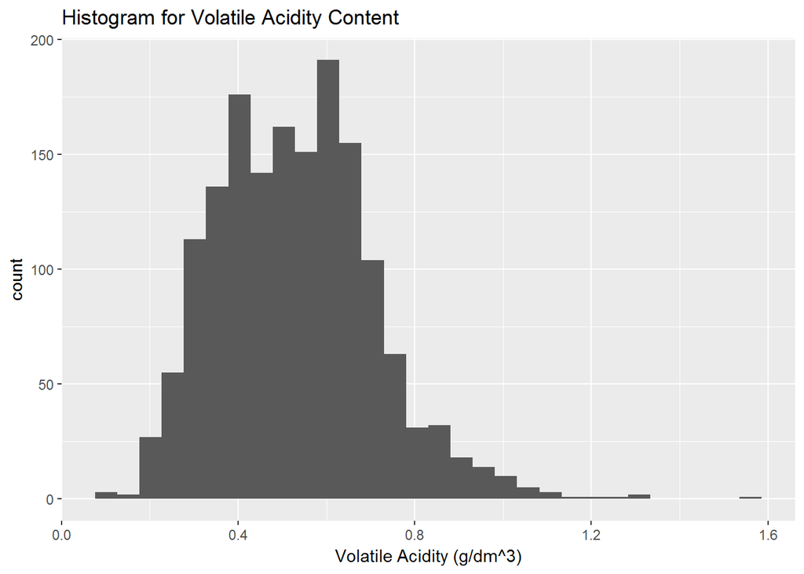

```r
summary(rw$volatile.acid)
```

```
##    Min. 1st Qu.  Median    Mean 3rd Qu.    Max.
##  0.1200  0.3900  0.5200  0.5278  0.6400  1.5800
```

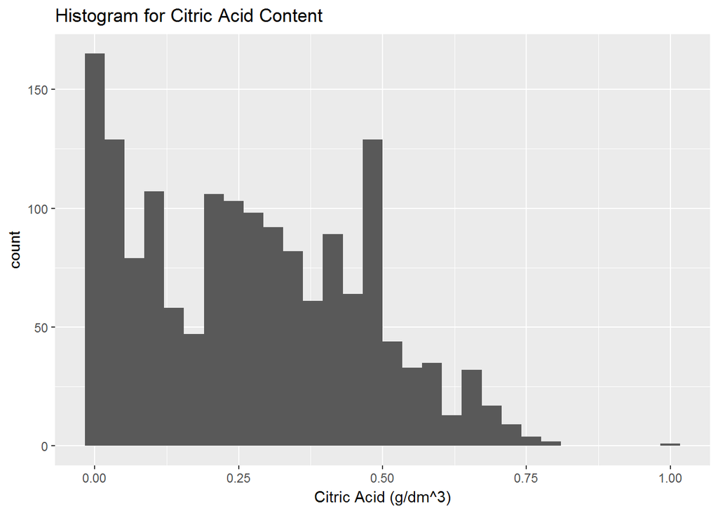

```r
summary(rw$citric.acid)
```

```
##    Min. 1st Qu.  Median    Mean 3rd Qu.    Max.
##   0.000   0.090   0.260   0.271   0.420   1.000
```

Citric Acid is skewed to the right. There’s an outlier detected at 1g/dm^3. What’s interesting about this histogram is the high occurrence of zero values in this variable. We will further analyse this Citric Acid scenario.

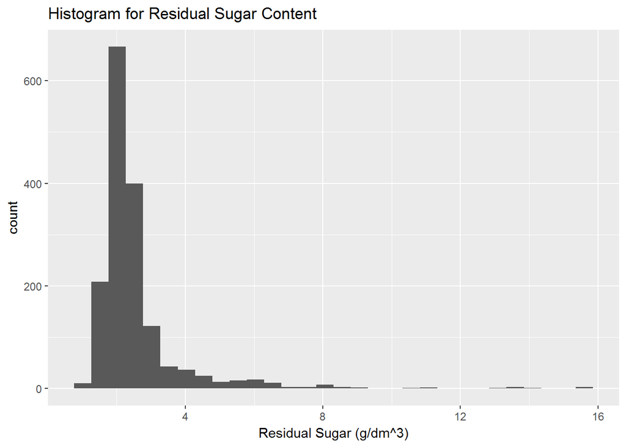

```r
summary(rw$residual.sugar)
```

```
##    Min. 1st Qu.  Median    Mean 3rd Qu.    Max.
##   0.900   1.900   2.200   2.539   2.600  15.500
```

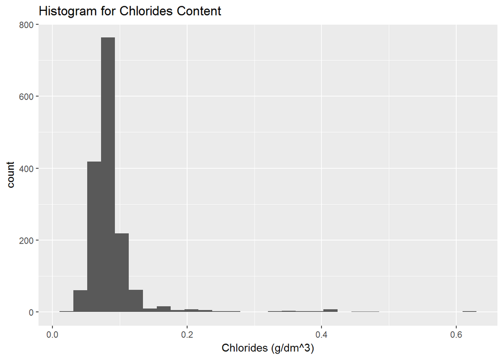

```r
summary(rw$chlorides)
```

```
##    Min. 1st Qu.  Median    Mean 3rd Qu.    Max.
## 0.01200 0.07000 0.07900 0.08747 0.09000 0.61100
```

Chlorides histogram is almost similar to the Residual Sugar histogram above as it was skewed to the right with some outliers that go beyond 0.3g/dm^3. And just like Residual Sugar, these outliers do not have big influence to the mean score (Mean score for Chlorides variable is 0.08747g/dm^3).

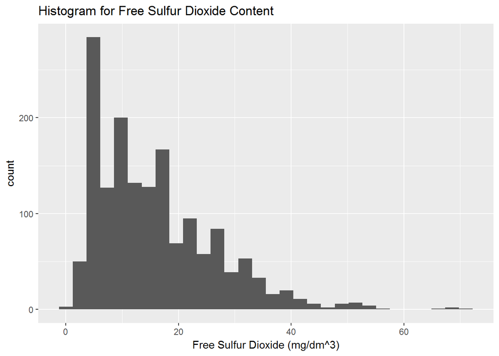

```r
summary(rw$free.sulfur.dioxide)
```

```
##    Min. 1st Qu.  Median    Mean 3rd Qu.    Max.
##    1.00    7.00   14.00   15.87   21.00   72.00
```

We see another histogram that skewed to the right. Outliers were detected that go beyond 60mg/dm^3. From the Summary function, we can see that the maximum value of Free Sulfur Dioxide was detected at 72mg/dm^3.

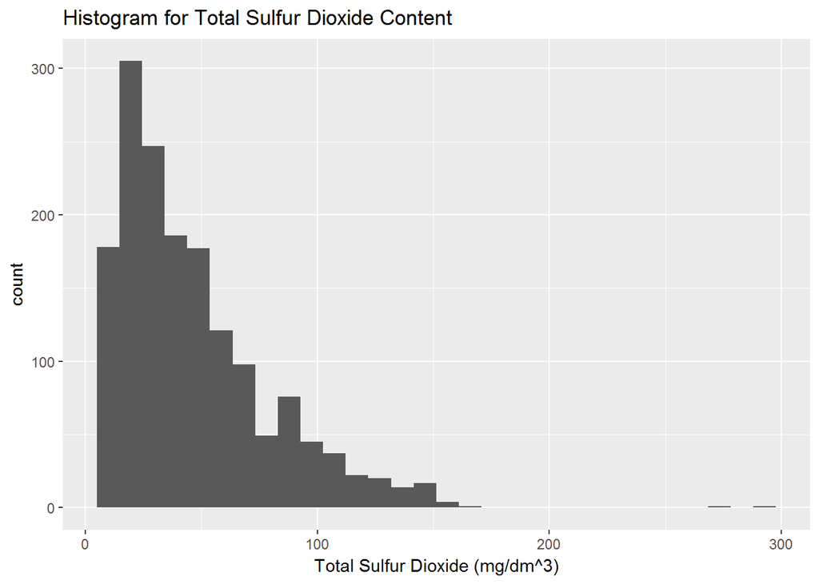

```r
summary(rw$total.sulfur.dioxide)
```

```
##    Min. 1st Qu.  Median    Mean 3rd Qu.    Max.
##    6.00   22.00   38.00   46.47   62.00  289.00
```

The histogram for Total Sulfur Dioxide is similar to the Free Sulfur Dioxide. Perhaps the similarity is due to the fact Free Sulfur contributes majorly to the Total Sulfur content. However, there are some worrying outlier in this histogram. You can see we have a few datapoints that go above 160mg/dm^3.

```r
sum(rw$total.sulfur.dioxide>160)
```

```
## [1] 3
```

According to this [(website)](http://www.scientistlive.com/content/total-sulphite-wine), the permitted level of SO2 (Sulfur Dioxide) in Red Wine is 160mg/l (160mg/dm^3) in the EU (European Union). There are three datapoints that go above that level in this dataset. We do not know if this is simply a human error, or if the datapoint is actually legit. However, we will be keeping these datapoints in the analysis since we are looking at the factors that contributes the quality of the wine.

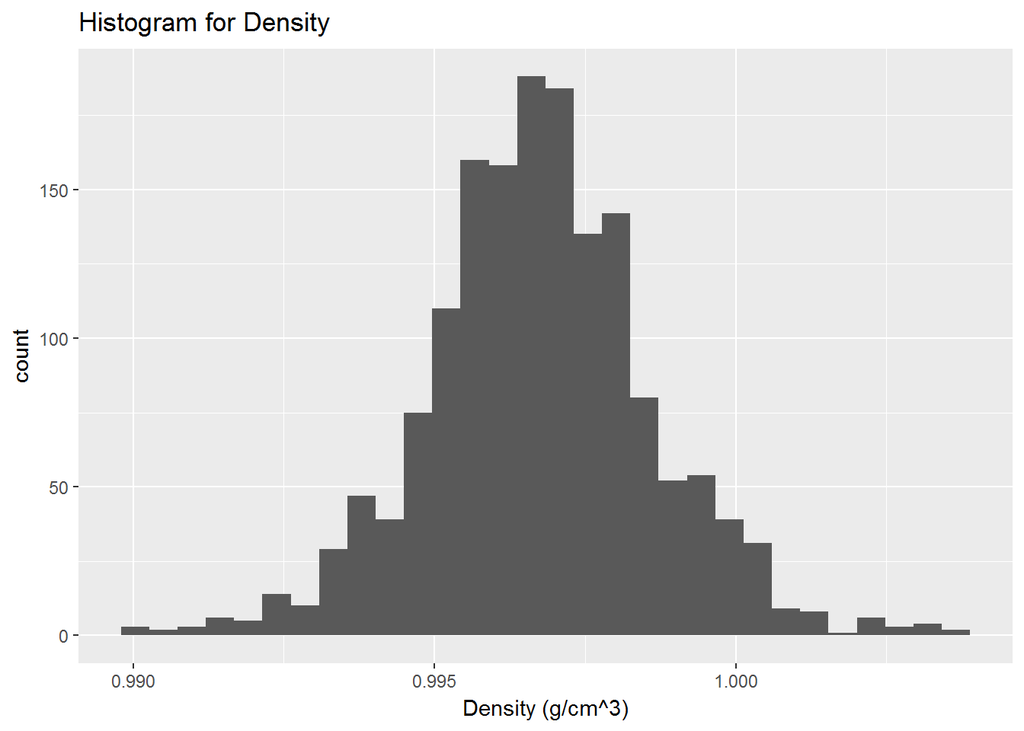

```r
summary(rw$density)
```

```
##    Min. 1st Qu.  Median    Mean 3rd Qu.    Max.
##  0.9901  0.9956  0.9968  0.9967  0.9978  1.0037
```

The distribution for Density follows a normal distribution shape.The mean for Density in this red wine is 0.9967g/cm^3, which is really close to the median score of 0.9968g/cm^3.

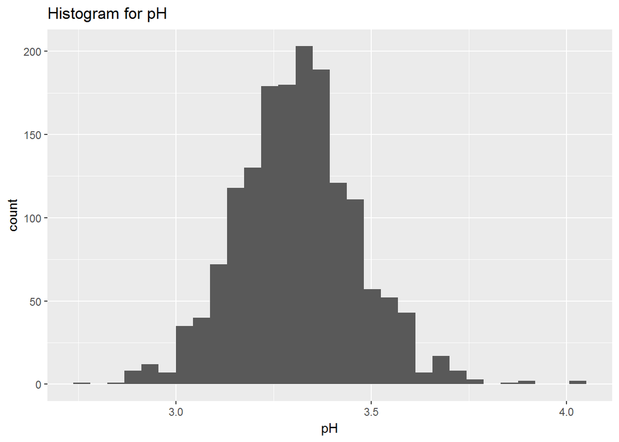

```r
summary(rw$pH)
```

```
##    Min. 1st Qu.  Median    Mean 3rd Qu.    Max.
##   2.740   3.210   3.310   3.311   3.400   4.010
```

Just like Density, the pH histogram also follows the normal distribution shape.The median and the mean for this distribution is really close to each other, a pH of 3.310 as a median and 3.311 as the mean pH.

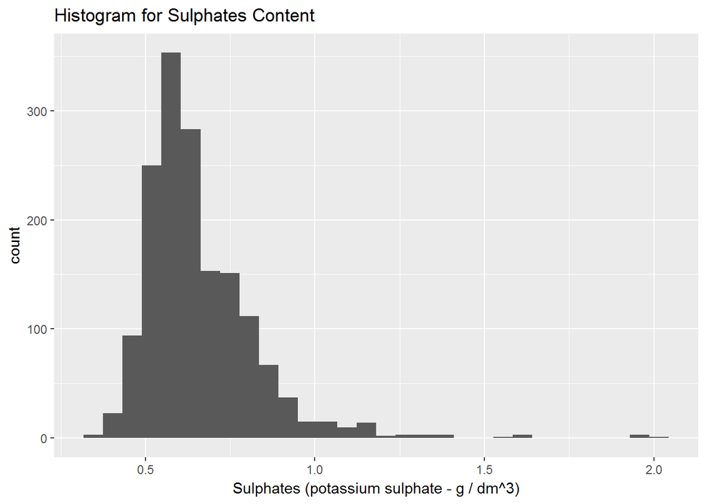

```r
summary(rw$sulphates)
```

```
##    Min. 1st Qu.  Median    Mean 3rd Qu.    Max.
##  0.3300  0.5500  0.6200  0.6581  0.7300  2.0000
```

Here, we find another histogram that skewed to the right. Some outliers were detected above 1.5g/dm^3.

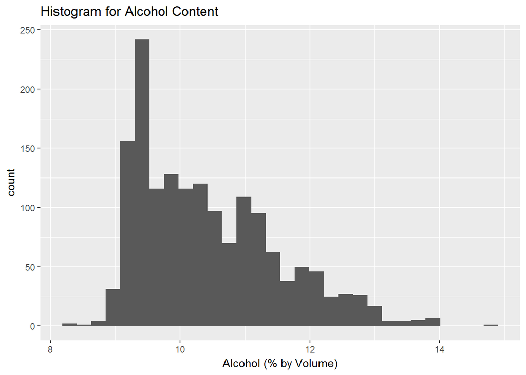

```r
summary(rw$alcohol)
```

```
##    Min. 1st Qu.  Median    Mean 3rd Qu.    Max.
##    8.40    9.50   10.20   10.42   11.10   14.90
```

Like most of the histograms in this dataset, Alcohol volume histogram is also skewed to the right. We can also detected an outlier that occur at 14.9%.

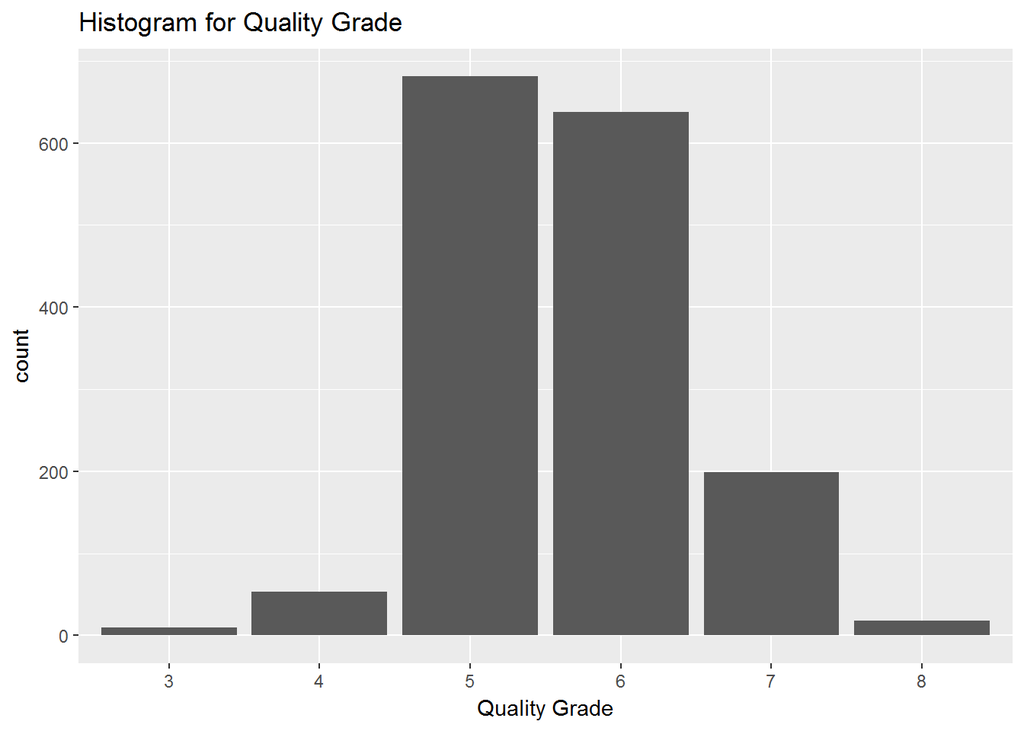

```r
summary(rw$quality)
```

```
##    Min. 1st Qu.  Median    Mean 3rd Qu.    Max.
##   3.000   5.000   6.000   5.636   6.000   8.000
```

```r
summary(rw$quality.factor)
```

```
##   3   4   5   6   7   8
##  10  53 681 638 199  18
```

The Quality histogram follows a normal distribution. Most the wine in this datasets falls in Grade 5 Quality.

Overall, it seems Density, pH and Quality has normal distribution.There are some outliers found in Chlorides, Total Sulphates, Residual Sugar, Free Sulfur dioxide and Total Sulfur Dioxide. Interesting to also note that Citric Acid has a few data with zero value.

Seven of the these histograms are skew to the right. We will then transform these using log10 so that their distribution will be normalised, thus, make it easier to apply the statistical formula for future analysis.

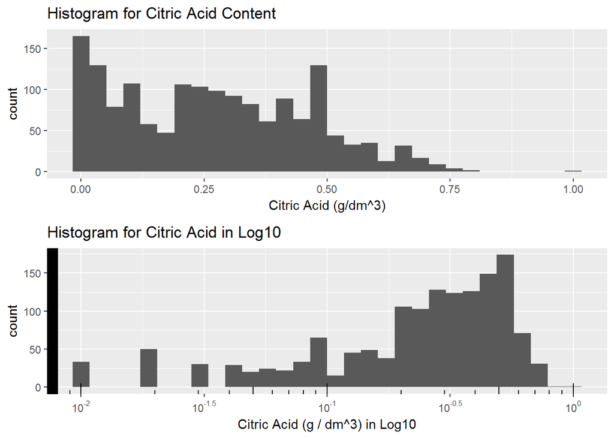

I expected the histogram for Citric Acid in Log10 to at least looks like a normal distribution. However, it ends up skewed to the left (from the original that skewed to the right). Perhaps if we removed some of the outliers, we could have an acceptable normal distribution.

However, I won’t be removing the outliers because I am interested to further my investigation in the Citric Acid dataset, especially the datapoints that contain zero citric acid value.

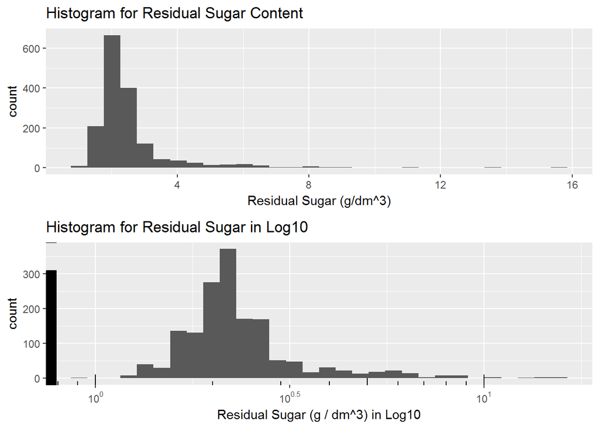

The Residual Sugar in Log10 looks somewhat, ‘normal-ish’ in its distribution. I will accept that we have successfully transformed it into normal distribution.

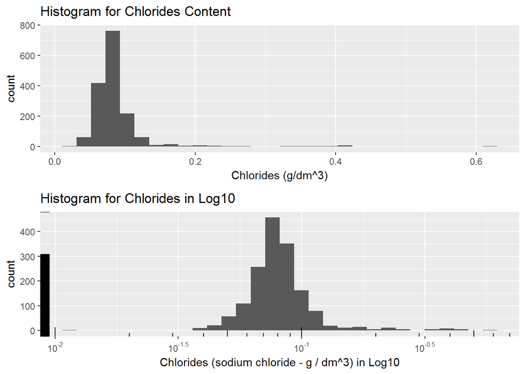

We also managed to transform Chlorides into normal distribution using Log10.

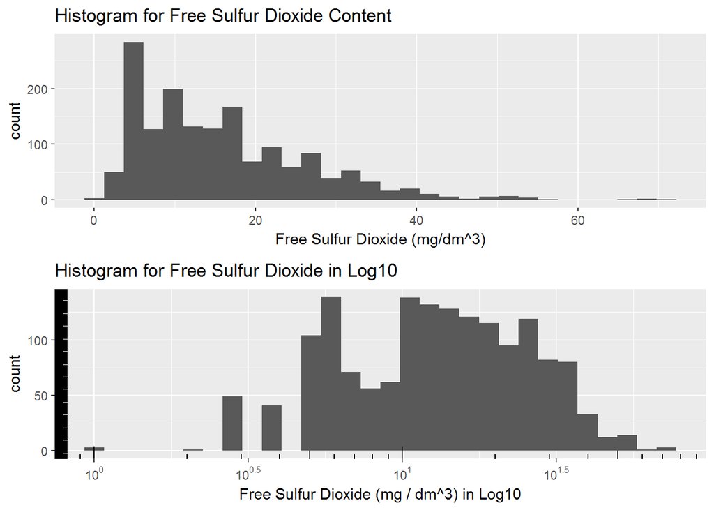

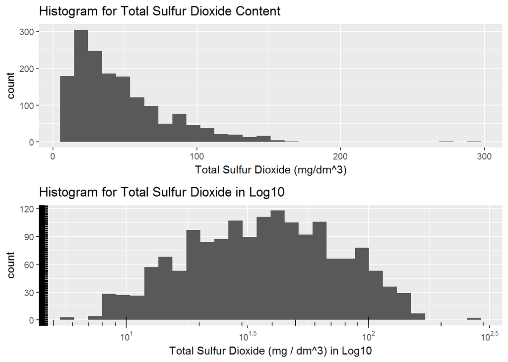

Total Sufur Dioxide was successfully transformed to a normal distribution using Log 10.

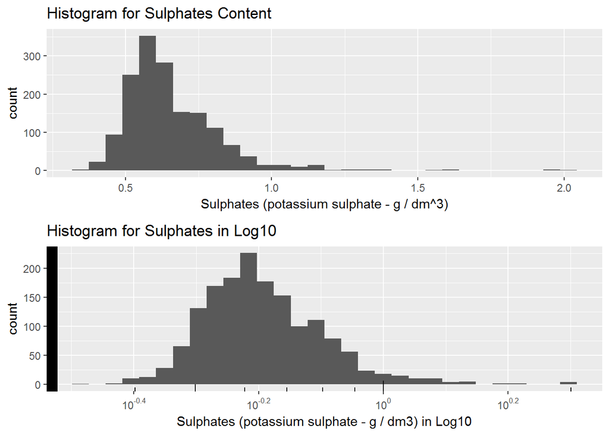

Sulphates is another variable that we have successfully transfored using Log10.

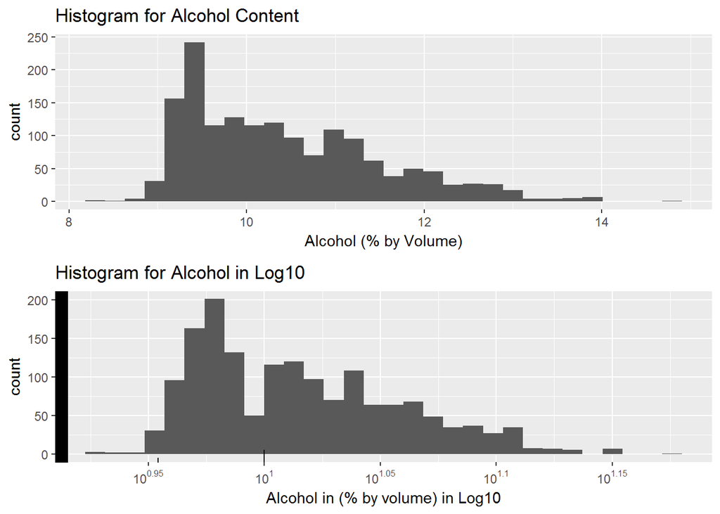

There’s not much changes in Alcohol distribution shape after we have transformed them using Log10.

As a result, Residual Sugar, Chlorides,Total Sulfur Dioxide and Sulphates have shown a normal distribution after the Log10 transformation.

### Citric Acid Issue:-

From the histogram above, it seems Citric Acid has a lot of zero values in it.In fact, the mode for Citric Acid is 0. We will be comparing the Citric Acid Histogram and Citric Acid Boxplot in the graph below:-

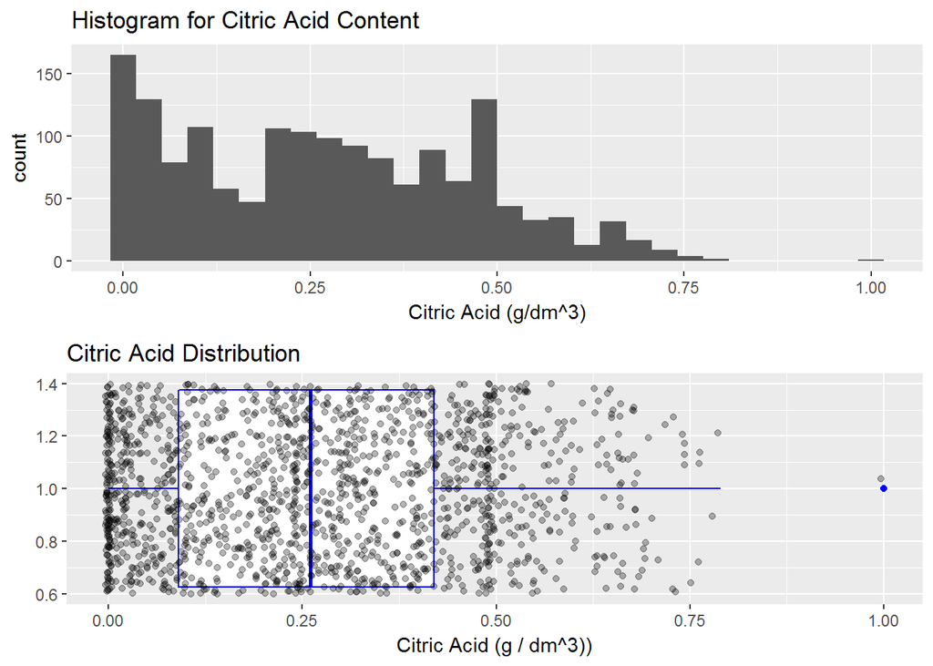

From the visuals above, we can see that this Red Wine dataset contains wine with no citric acid. I want to know if these zero value will bring problem in later analysis. However, I’m assuming that the the zero citric acid value is balanced by other type of acids in the wine, namely, the fixed and volatile acids.

First, I’m going to check the data that contains Zero Citric Acid:

```r
length(subset(rw, citric.acid == 0)$citric.acid)
```

```
## [1] 132
```

There are 132 data with no citric acid in them. Then, we extract those data into another dataset called zero.citric

```r
zero.citric<- subset(rw, rw$citric.acid==0)
```

Finally, we will do a comparison with other type of acids: The Fixed and Volatile:

```r
data_zero.citric <- list(zero.citric$fixed.acidity,zero.citric$volatile.acidity)
lapply(data_zero.citric,summary)
```

```
## [[1]]
##    Min. 1st Qu.  Median    Mean 3rd Qu.    Max.
##   4.900   6.500   7.100   6.998   7.525   9.100
##
## [[2]]
##    Min. 1st Qu.  Median    Mean 3rd Qu.    Max.
##  0.3400  0.6000  0.6675  0.6922  0.7612  1.5800
```

The results from the summary has shown even though the value of citric.acid is zero, the other type of acid such as fixed and volatile do exist in the wine content since their minimum value is above zero.

# Univariate Analysis

### What is the structure of your dataset?

From the str(rw) function result, we can see that this Dataset contains 1599 observations with 12 variables (after we remove the index variable X)

### What is/are the main feature(s) of interest in your dataset?

Since this dataset comes from a study on Red Wine Quality, then, Quality will be the main target in this exploration. However, I’m also interested in the lack of citric acid in some of the samples and whether it’s going to play a major influence in the quality of the red wine.

### What other features in the dataset do you think will help support your investigation into your feature(s) of interest?

I will also investigate the other type of acids (fixed and volatile) and whether it will play a role in determine the quality.

### Did you create any new variables from existing variables in the dataset?

I created a new dataset called Zero.Citric that extract the data with zero citric acid value. We may do further analysis on this particular dataset.

### Of the features you investigated, were there any unusual distributions? Did you perform any operations on the data to tidy, adjust, or change the form of the data? If so, why did you do this?

I transformed seven histogram into log10. And amongst these- Residual Sugar, Chlorides,Total Sulfur Dioxide and Sulphates shown a normal distribution after transformation. We can proceed to use the Normal Distribution analysis for these variables (if needed in the future)

# Bivariate Plots Section

Firstly, I want to see if there’s any relation between Acid and pH. To do this, we will create a new variable called total.acid

```r
rw$total.acid<-rw$fixed.acidity + rw$volatile.acidity + rw$citric.acid
summary(rw$total.acid)
```

```
##    Min. 1st Qu.  Median    Mean 3rd Qu.    Max.
##   5.270   7.827   8.720   9.118  10.070  17.045
```

Then we plot the new variable (total.acid) against pH

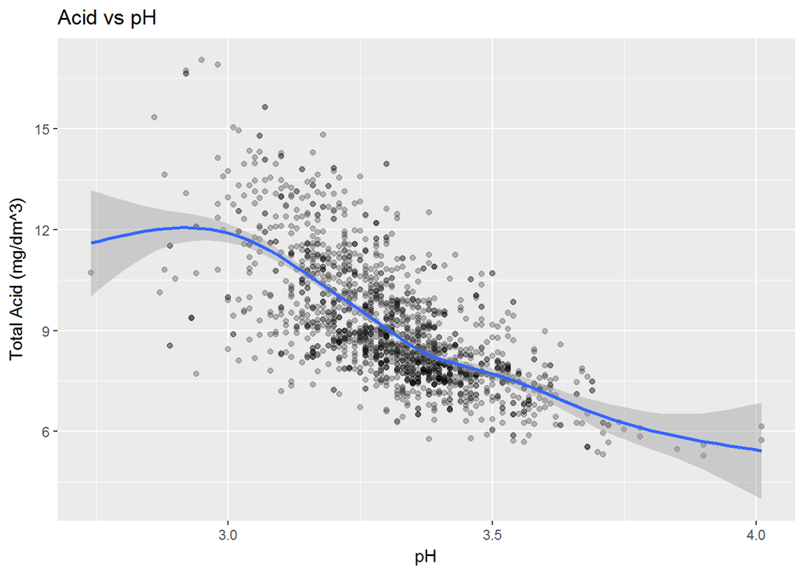

It looks like there is a correlation between Acid and pH based on the blue line. And to confirm further, we will be running a correlation test.

```r
cor(rw$total.acid, rw$pH)
```

```
## [1] -0.6834838
```

The result shows a pretty strong correlation between Acid and pH.

Once we are satisfied with this result, the next step is to finally looking into the role citric acid plays in making a good quality red wine.

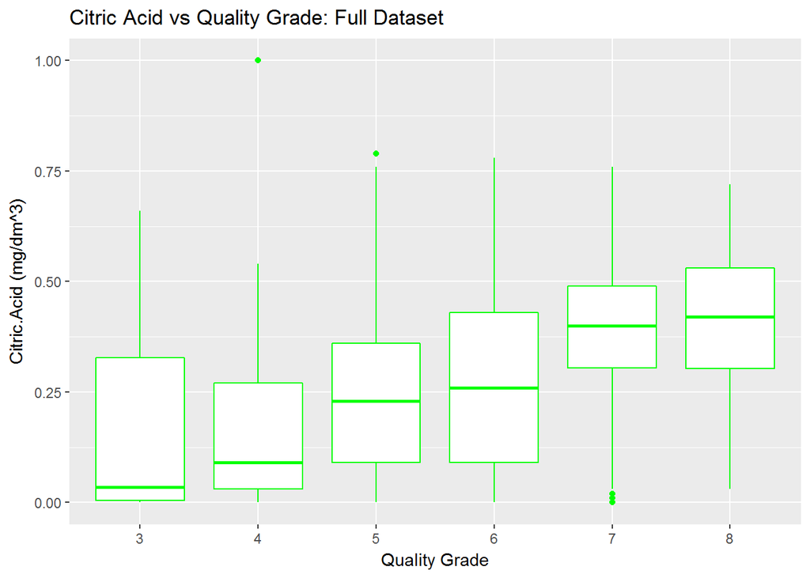

We can see from the boxplot above that the highest citric acid mean is situated under Grade 8 Quality (at around 0.4mg/dm^3). While the lowest quality, Grade 3, has the lowest Citric Acid mean (at around 0.05mg/dm^3).

Let’s run the summary function Quality in Zero.Citric dataset.

```r
#check the quality value in the data with zero citric acid
summary(zero.citric$quality)
```

```
##    Min. 1st Qu.  Median    Mean 3rd Qu.    Max.
##   3.000   5.000   5.000   5.409   6.000   7.000
```

We will do a correlation test for this question:

```r
cor(rw$citric.acid, rw$quality)
```

```
## [1] 0.2263725
```

There seems to be some correlation there. It’s not strong, but it seems to influence your wine quality to some degree.

We will then proceed to plot other type of acid against quality. We’re going to start with Volatile Acid.

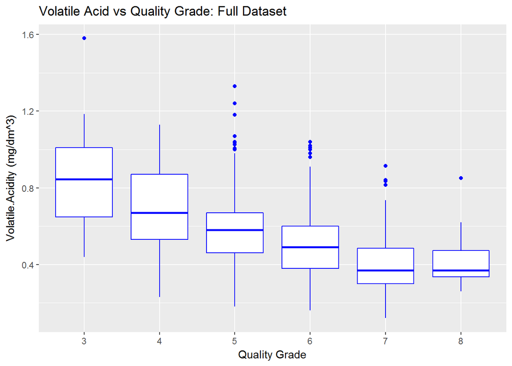

The highest wine grade contains a low volume of volatile acide. We will be running a correlation test to confirm this plot.

```r
cor(rw$volatile.acid, rw$quality)
```

```
## [1] -0.3905578
```

At -0.39, the volatile acid does have a stronger influence to the red wine quality compared to citrict acid. We will then plot fixed acid against quality.

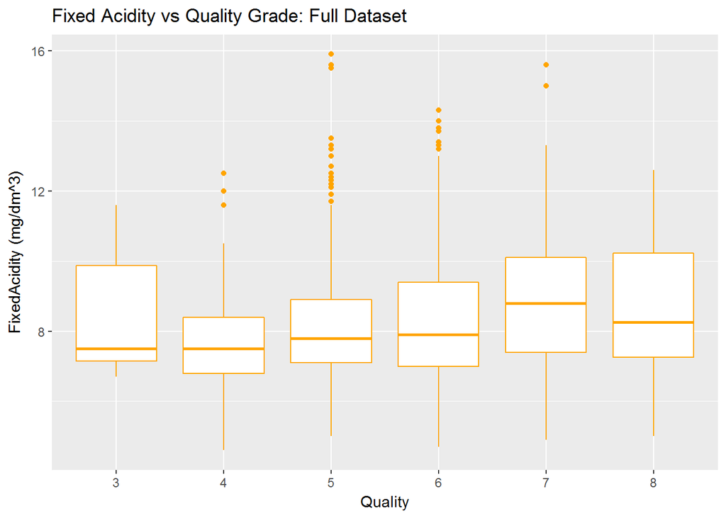

There seems to be not much correlation from what we’ve seen. The plot is scattered all over the place. So we will confirm this with correlation test.

```r
cor(rw$fixed.acid, rw$quality)
```

```
## [1] 0.1240516
```

The correlation is pretty miniscule.

So what are other variables that can influence quality? To get an overview of this, I’ll be running a ggcor function

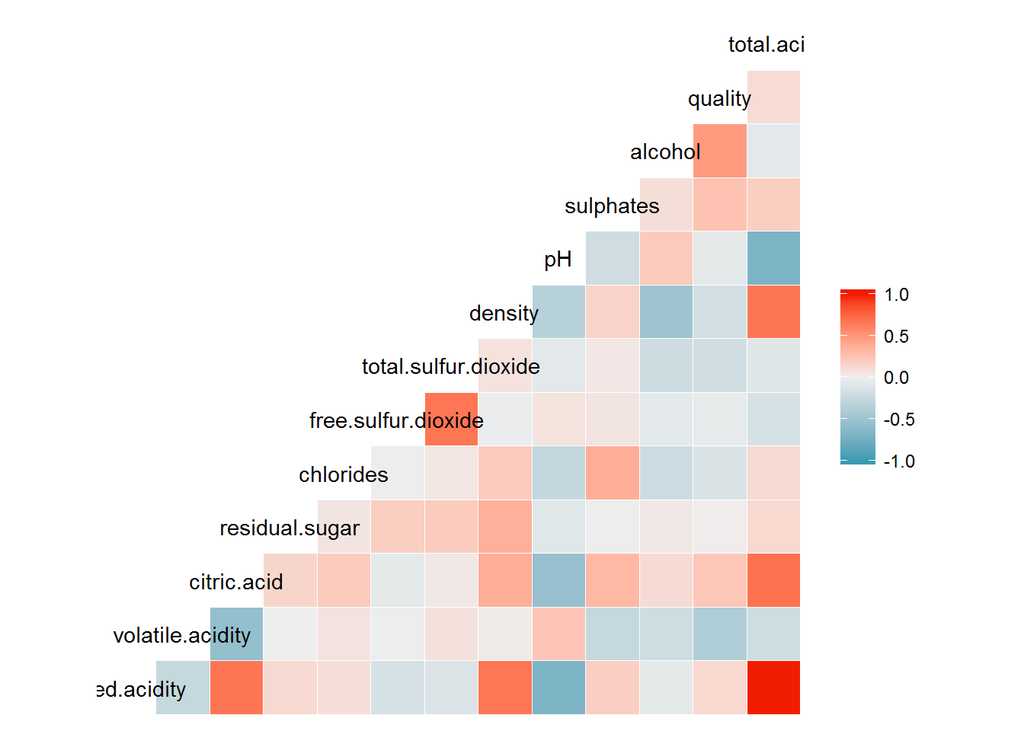

```r
ggcorr(rw)
```

Since I’m interested in identifying the factor that made a good quality wine, I’m just going to zoom into Quality column. Amongst the variables, the highest correlation to be found is between Alcohol volume and Quality, so we will be plotting these two variables.

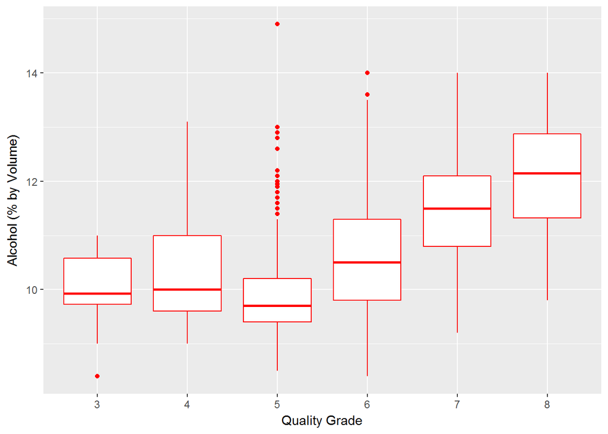

```r
#calculate the Alcolhol Volume mean for Grade 8
Grade8<-subset(rw, rw$quality==8)
mean(Grade8$alcohol)
```

```
## [1] 12.09444
```

The highest mean in Alcohol Volume was found in the highest quality grade (Grade 8) at 12.09%.

I wonder if we will see the same composition in the dataset with zero citric acid.

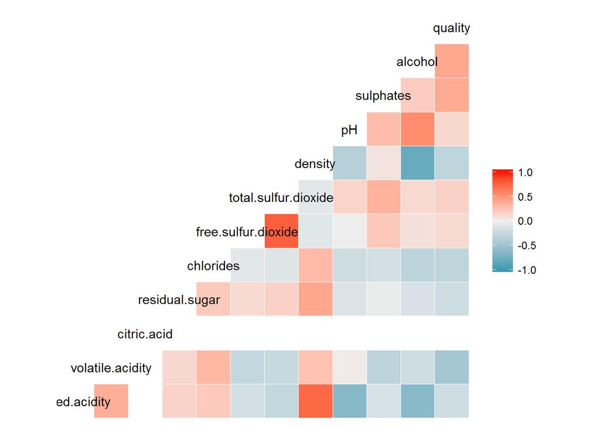

```r
ggcorr(zero.citric)
```

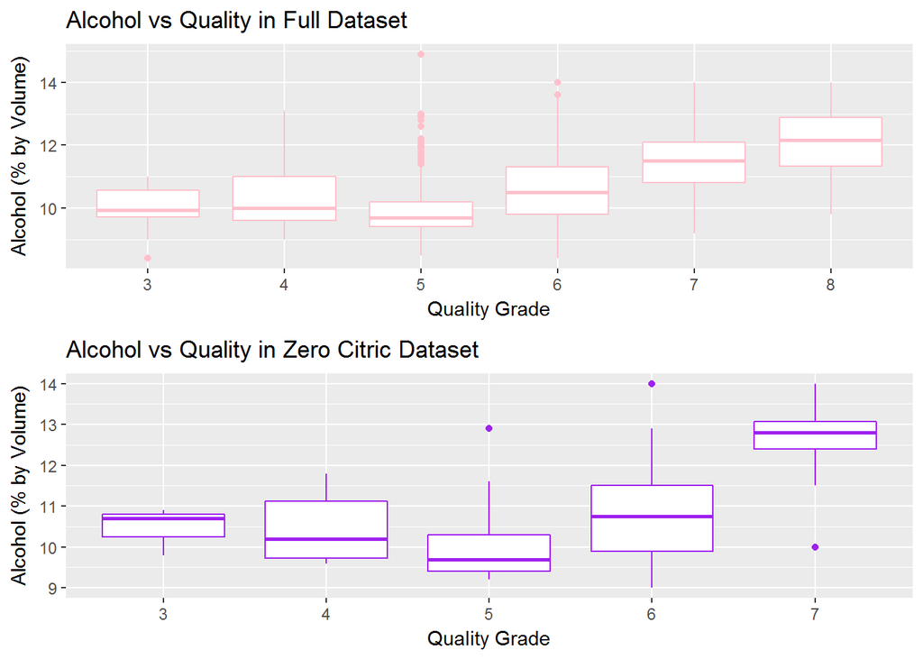

There seems to be a big jump in mean between Grade 6 and Grade 7 in Zero Citric Dataset.

```r
Grade7rw<-subset(rw, rw$quality==7)
mean(Grade7rw$alcohol)
```

```
## [1] 11.46591
```

```r
Grade7zc<-subset(zero.citric, zero.citric$quality==7)
mean(Grade7zc$alcohol)
```

```
## [1] 12.5375
```

The calculation above shows a higher Alcohol percentage mean in wine with no Citric Acid (mean=12.53%) compared to the wine in full dataset (mean=11.47%) under Grade 7 datapoints, aka, the highest quality found in Zero Citric dataset, (since Zero Citric dataset did not contain Grade 8 Quality).

Is there a strong relation between alcohol and citric acid? Perhaps you need to add more alcohol content into your wine to compensate the lack of citric acid? With this in mind, I’m going to plot Citric Acid vs Alcohol Volume using the full dataset.

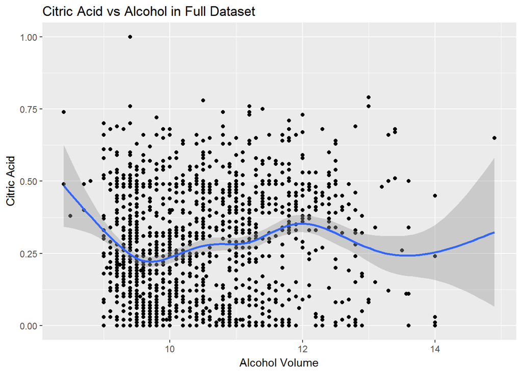

```r
cor(rw$alcohol, rw$citric.acid)
```

```
## [1] 0.1099032
```

Not much of a correlation there . And it’s confirmed by the correlation score. Perhaps it comes from another type of acid?

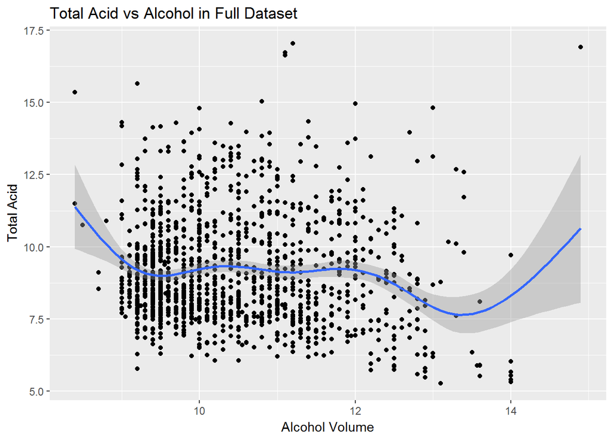

```r
cor(rw$alcohol, rw$total.acid)
```

```
## [1] -0.06666786
```

No correlation to be found between Total Acid and Alcohol Volume too. It looks like some other variables were influencing the drop in correlation score between Alcohol and Quality in the Zero Citric Acid dataset.